# 6.2. Permutation test - Checking observed vs expected values

Lorenzo Bertola

Document last run on 2024-07-02

Now we will assess whether the number of sex-linked markers is significantly more than expected by chance, by comparing the observed number to the expected distribution derived from the permutations.

## 0. Load packages and input data

```r
library(tidyverse)
library(ggpubr)
```

Read input from permutations for all pops

```r
#read list of file names
my.perms <- list.files(path = "../6_Permutations/1_Results/",
                       pattern = "6_1_PermTest_Results_P",
                       full.names = TRUE)

#extract pop names
my.names <- substr(my.perms,51,53)
my.names <- gsub("\\.","",my.names)

#names elements of list
names(my.perms) <- my.names

#read in all perm files
my.perms <- lapply(my.perms, function(x){
  y <- read_delim(x, delim = "\t")

  return(y)
})

#add column with pop name
my.perms <- mapply(function(x,y){
  z <- x %>% add_column("Pop"=y)

  return(z)
}, my.perms,my.names, SIMPLIFY = FALSE)

#bind all dataframes
my.perms <- bind_rows(my.perms)
```

Check structure

```r
glimpse(my.perms)
```

```
## Rows: 21,326,682
## Columns: 6
## $ markerID <chr> "scaffold_6_59725051", "scaffold_2_50244712", "scaffold_13_32…
## $ Method   <chr> "Method1", "Method1", "Method1", "Method1", "Method1", "Metho…
## $ SexDet   <chr> "ZW", "XY", "ZW", "ZW", "ZW", "XY", "ZW", "XY", "XY", "XY", "…
## $ Side     <chr> "REF", "REF", "REF", "REF", "REF", "REF", "REF", "REF", "REF"…
## $ PermID   <dbl> 46, 67, 222, 283, 335, 348, 436, 470, 470, 470, 479, 483, 499…
## $ Pop      <chr> "P1", "P1", "P1", "P1", "P1", "P1", "P1", "P1", "P1", "P1", "…
```

Add column containing scaffold number

```r
my.perms <- my.perms %>%
  mutate(Scaffold = gsub("^([^_]*_)([^_]*)_.*$", "\\2", markerID),
         .after = markerID)
```

Save list of markers identified during permutations

```r
write_csv(my.perms, file = "../6_Permutations/6_2_PermTest_MarkerList.csv")
```

Now, let's import the list of sex-linked markers identified with the true sex assignment

```r
my.df.1 <- read_delim("../5_SexLinked/5_1_SexlinkedMarkers_LS.tsv",
                      delim = "\t")
my.df.2 <- read_delim("../5_SexLinked/5_1_SexLinkedMarkers_LN.tsv",
                      delim = "\t")
my.df.3 <- read_delim("../5_SexLinked/5_1_SexLinkedMarkers_LM.tsv",
                      delim = "\t")

my.df <- rbind(my.df.1,my.df.2,my.df.3)
rm(my.df.1,my.df.2,my.df.3,my.names)
```

Save dataframe of sex-linked markers identified with true sex assignment

```r
write_csv(my.df, file = "../5_SexLinked/5_2_SexLinked_All.csv")
```

## 1. Observed sex-linked markers

Let's calculate how many XY and how many ZW were found for each method for each pop.

```r
counts <- my.df %>% group_by(Pop, Method, SexDet) %>%
  summarise(sexlinked = table(SexDet))
AllCombs <- expand_grid(Pop = c("P1","P2","P3","P4","P5","P6","P7",
                                "P8","P9","P10","P11","P12","P13",
                                "P14","P15"),
                        Method = c("Method1","Method2","Method3",
                                   "Method4","Method5"),
                        SexDet = c("XY","ZW"))

counts <- left_join(AllCombs, counts) %>%
  mutate(sexlinked = case_when(is.na(sexlinked) == TRUE ~ as.integer(0),
                       TRUE ~ as.integer(sexlinked) ))
```

Let's visualise it

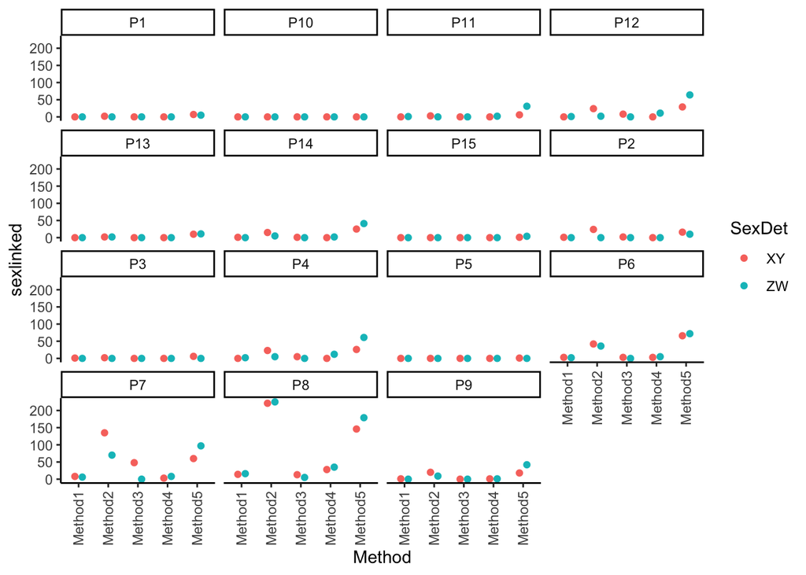

```r
ggplot(counts) +
  geom_point(aes(y=sexlinked,x=Method,
                 fill=SexDet, colour=SexDet),
             position = position_dodge(width = 0.5)) +
  facet_wrap(~Pop) + theme_classic() +
  theme(axis.text.x = element_text(angle = 90, vjust = 0.5, hjust=1))
```

### 1.1 Observed sex-linked markers by scaffold

Let's also assess where they occur across the 13 largest scaffolds

```r
#retain only 13 scaffolds (95% of genome)
my.df.13 <- my.df %>% filter(Scaffold < 14)

my.df.13$Scaffold <- as_factor(my.df.13$Scaffold)

#make a list with one element per population
my.pops <- c("P1","P2","P3","P4","P5","P6","P7","P8",
             "P9","P10","P11","P12","P13","P14","P15")

my.df.13.list <- lapply(my.pops, function(x){
  y <- my.df.13 %>% filter(Pop==x)

  return(y)
})

#make one plot per population
my.plots <- lapply(my.df.13.list, function(x){
  p <- ggplot(x) +
    geom_point(aes(x=Position/1000000, y = 1, fill=SexDet, colour=SexDet),
               position = position_jitter(width = 0, height = 0.1)) +
    facet_wrap(~Scaffold, drop = FALSE, nrow=1,ncol=13)+
    theme_bw() +
    xlab("Position (Mb)") +
    scale_x_continuous(limits = c(0,300)) +
    theme(axis.text.y = element_blank(),
        axis.title.y = element_blank(),
        axis.ticks.y = element_blank(),
        axis.text.x = element_text(angle = 90, vjust = 0.5, hjust=1),
        panel.grid.major.y = element_blank(),
        panel.grid.minor.y = element_blank())

  return(p)
})
```

Do a plot per lineage

```r
plot.LN <- ggarrange(my.plots[[6]] + theme(axis.title.x = element_blank()),
                      my.plots[[7]] + theme(axis.title.x = element_blank()),
                      my.plots[[8]] + theme(axis.title.x = element_blank()),
                      my.plots[[9]] + theme(axis.title.x = element_blank()),
                      my.plots[[10]],
                      ncol = 1, nrow = 5, common.legend = TRUE, legend = "right",
                      align = "hv")

plot.LM <- ggarrange(my.plots[[11]] + theme(axis.title.x = element_blank()),
                      my.plots[[12]] + theme(axis.title.x = element_blank()),
                      my.plots[[13]] + theme(axis.title.x = element_blank()),
                      my.plots[[14]] + theme(axis.title.x = element_blank()),
                      my.plots[[15]],
                      ncol = 1, nrow = 5, common.legend = TRUE, legend = "right",
                      align = "hv")

plot.LS <- ggarrange(my.plots[[1]] + theme(axis.title.x = element_blank()),
                      my.plots[[2]] + theme(axis.title.x = element_blank()),
                      my.plots[[3]] + theme(axis.title.x = element_blank()),
                      my.plots[[4]] + theme(axis.title.x = element_blank()),
                      my.plots[[5]],
                      ncol = 1, nrow = 5, common.legend = TRUE, legend = "right",
                      align = "hv")
```

And export them for easier viewing.

```r
ggsave("../6_Permutations/6_2_SexLinkedByScaffold_LN.png",plot = plot.LN,
       device = "png",dpi = 300, width = 20, height = 12)
ggsave("../6_Permutations/6_2_SexLinkedByScaffold_LM.png",plot = plot.LM,
       device = "png",dpi = 300, width = 20, height = 12)
ggsave("../6_Permutations/6_2_SexLinkedByScaffold_LS.png",plot = plot.LS,
       device = "png",dpi = 300, width = 20, height = 12)
```

Note the very clear signal in P1 (LS-BC), P2 (LS-LC) and P3 (LS-Pal) on scaffold 5.

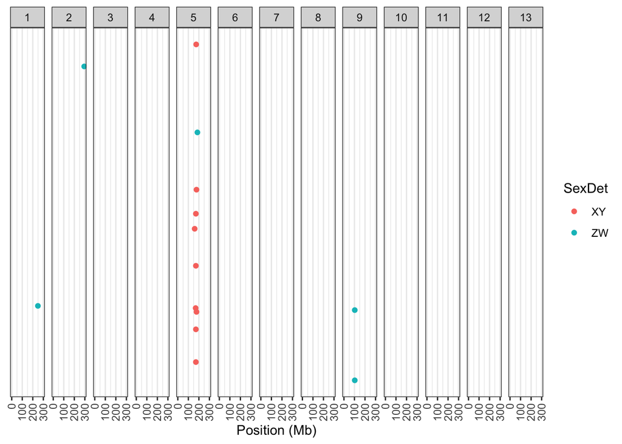

```r
my.plots[[1]]
```

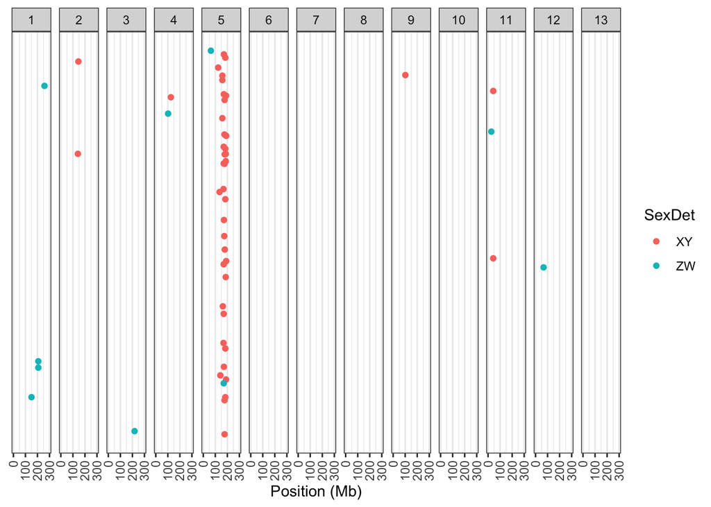

```r
my.plots[[2]]
```

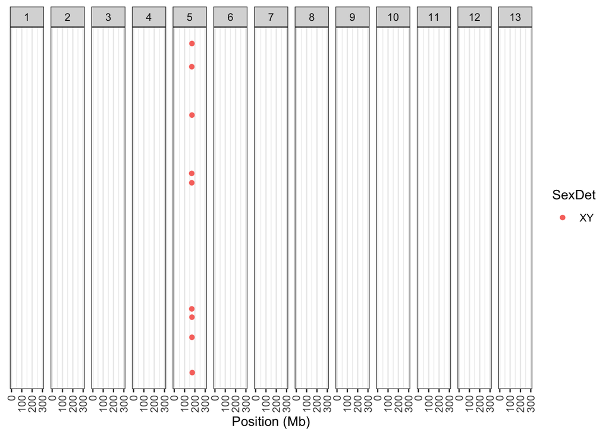

```r
my.plots[[3]]
```

Remove now redundant objects

```r
rm(my.df.13, my.df.13.list, my.plots, plot.LM, plot.LS, plot.LN)
```

## 2. Expected sex-linked markers

Now we want to calculate how many sex-linked markers were obtained **on average** for each method during permutations.

```r
XY <- my.perms %>%
  filter(SexDet=="XY") %>%
  group_by(Pop, Method) %>%
  count(PermID)

ZW <- my.perms %>%
  filter(SexDet=="ZW") %>%
  group_by(Pop, Method) %>%
  count(PermID)
```

Add rows with 0 for permutations that found no sex-linked markers

```r
Pop <- c("P1","P2","P3","P4","P5","P6","P7","P8","P9","P10","P11","P12","P13","P14","P15")
Method <- c("Method1","Method2","Method3","Method4","Method5")
PermID <- seq(1,10000,1)

AllCombs <- expand_grid(Pop,Method,PermID)

XY <- left_join(AllCombs,XY) %>% mutate(n = case_when(is.na(n) == TRUE ~ as.integer(0),
                                                      TRUE ~ as.integer(n) ))
ZW <- left_join(AllCombs,ZW) %>% mutate(n = case_when(is.na(n) == TRUE ~ as.integer(0),
                                                      TRUE ~ as.integer(n) ))
rm(Pop,Method,PermID,AllCombs)
```

Keep current format for plotting violin plots later

```r
XY.1 <- XY %>% add_column("SexDet"="XY")
ZW.1 <- ZW %>% add_column("SexDet"="ZW")

XYZW <- rbind(XY.1, ZW.1)

rm(XY.1, ZW.1)
```

Calculate mean and quantiles per pop per method.

```r
XY <- XY %>%
  group_by(Pop, Method) %>%
  summarise(quant95 = quantile(n,0.95),
            quant99 = quantile(n,0.99),
            average = mean(n)) %>%
  add_column("SexDet"="XY")
```

[output not shown]

```r
ZW <- ZW %>%
  group_by(Pop, Method) %>%
  summarise(quant95 = quantile(n,0.95),
            quant99 = quantile(n,0.99),
            average = mean(n)) %>%
  add_column("SexDet"="ZW")
```

[output not shown]

```r
perm.counts <- rbind(XY,ZW)

rm(XY,ZW)
```

Now merge with observed values

```r
counts <- left_join(counts,perm.counts)
```

Add column with significance

```r
counts <- counts %>%
  mutate(significance = case_when(sexlinked > quant99 ~ "**",
                                      sexlinked > quant95 ~ "*",
                                      sexlinked > average ~ "above.average",
                                      TRUE ~ "NS"))
```

## 3. Plot results

Change pop names to match the map in Figure 1

```r
counts <- counts %>%
  mutate(Pop2 = case_when(Pop == "P1" ~ "LS-BC",
                         Pop == "P2" ~ "LS-LC",
                         Pop == "P3" ~ "LS-Pal",
                         Pop == "P4" ~ "LS-GK",
                         Pop == "P5" ~ "LS-All",
                         Pop == "P6" ~ "LN-DO",
                         Pop == "P7" ~ "LN-JC",
                         Pop == "P8" ~ "LN-SC",
                         Pop == "P9" ~ "LN-KR",
                         Pop == "P10" ~ "LN-All",
                         Pop == "P11" ~ "LM-KR-2022",
                         Pop == "P12" ~ "LM-West",
                         Pop == "P13" ~ "LM-KR-2001",
                         Pop == "P14" ~ "LM-JC",
                         Pop == "P15" ~ "LM-All"))

XYZW <- XYZW %>%
  mutate(Pop2 = case_when(Pop == "P1" ~ "LS-BC",
                         Pop == "P2" ~ "LS-LC",
                         Pop == "P3" ~ "LS-Pal",
                         Pop == "P4" ~ "LS-GK",
                         Pop == "P5" ~ "LS-All",
                         Pop == "P6" ~ "LN-DO",
                         Pop == "P7" ~ "LN-JC",
                         Pop == "P8" ~ "LN-SC",
                         Pop == "P9" ~ "LN-KR",
                         Pop == "P10" ~ "LN-All",
                         Pop == "P11" ~ "LM-KR-2022",
                         Pop == "P12" ~ "LM-West",
                         Pop == "P13" ~ "LM-KR-2001",
                         Pop == "P14" ~ "LM-JC",
                         Pop == "P15" ~ "LM-All"))
```

Make a list with one element per pop

```r
my.pops <- unique(counts$Pop2)

my.counts <- lapply(my.pops, function(x){
  y <- counts %>% filter(Pop2==x)

  return(y)
})

#my.perm.counts <- lapply(my.pops, function(x){
#  y <- perm.counts %>% filter(Pop2==x)
#
#  return(y)
#})

my.XYZW <- lapply(my.pops, function(x){
  y <- XYZW %>% filter(Pop2==x)

  return(y)
})
```

Now let's plot violin plots of expected number of sex-linked markers, with the observed numbers identified with true sex assignments overlayed. First, let's try with one population only

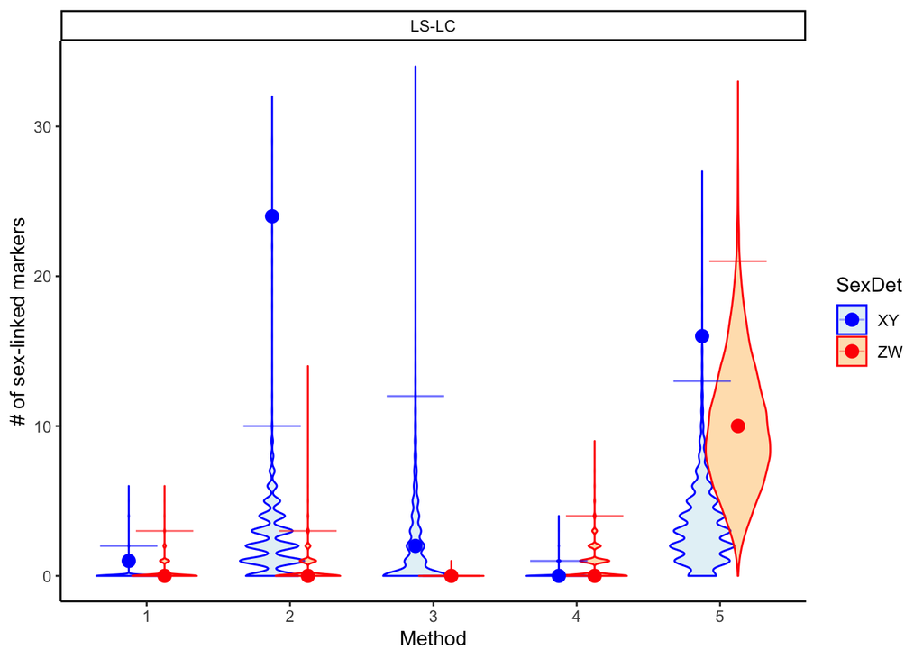

```r
ggplot() +
    geom_violin(data = my.XYZW[[2]], aes(x=Method,y=n,
                                          fill=SexDet, colour=SexDet),
                alpha = 1/3, scale = "width",
                position=position_dodge(width = 0.5)) +
    geom_errorbar(data = my.counts[[2]], aes(x=Method,
                                ymax=quant99,ymin=quant99,
                                colour=SexDet),
                  alpha = 1/3,width=0.8,
                position=position_dodge(width = 0.5)) +
    geom_point(data = my.counts[[2]], aes(x=Method,y=sexlinked,
                                          fill=SexDet, colour=SexDet),
               size=3, position=position_dodge(width = 0.5)) +
    scale_color_manual(values = c("XY" = "blue", "ZW" = "red")) +
    scale_fill_manual(values = c("XY" = "lightblue", "ZW" = "orange")) +
    scale_x_discrete(labels=c("Method1"="1","Method2"="2",
                              "Method3"="3","Method4"="4",
                              "Method5"="5")) +
    scale_y_continuous(name = "# of sex-linked markers") +
    facet_wrap(~Pop2, ncol = 1) + theme_classic()
```

Plot violin plots and the error bars representing the 99th quantile

```r
my.plots <- mapply(function(x,y){
  p <- ggplot() +
    geom_violin(data = y, aes(x=Method,y=n,colour=SexDet),
                fill="white",alpha = 1/3, scale = "width",
                position=position_dodge(width = 0.5)) +
    geom_errorbar(data = x, aes(x=Method,colour=SexDet,
                                ymax=quant99,ymin=quant99),
                  alpha = 1/3,width=0.8,
                  size=1.5,
                  position=position_dodge(width = 0.5)) +
    geom_point(data = x, aes(x=Method,y=sexlinked,colour=SexDet),
               size=3, position=position_dodge(width = 0.5)) +
    scale_color_manual(values = c("XY" = "black", "ZW" = "grey")) +
    #scale_color_manual(values = c("XY" = "blue", "ZW" = "red")) +
    #scale_fill_manual(values = c("XY" = "lightblue", "ZW" = "orange")) +
    scale_x_discrete(labels=c("Method1"="1","Method2"="2",
                              "Method3"="3","Method4"="4",
                              "Method5"="5")) +
    scale_y_continuous(name = "# of sex-linked markers") +
    facet_wrap(~Pop2, ncol = 1) + theme_classic() +
       theme(strip.text.x = element_text(size = 12, face="bold"))


  return(p)
}, my.counts,my.XYZW, SIMPLIFY = FALSE)
plot.all <- ggarrange(my.plots[[6]] + theme(axis.title.x = element_blank()),
                      my.plots[[7]] + theme(axis.title = element_blank()),
                      my.plots[[8]] + theme(axis.title = element_blank()),
                      my.plots[[9]] + theme(axis.title = element_blank()),
                      my.plots[[10]] + theme(axis.title = element_blank()),
                      my.plots[[11]] + theme(axis.title.x = element_blank()),
                      my.plots[[12]] + theme(axis.title = element_blank()),
                      my.plots[[13]] + theme(axis.title = element_blank()),
                      my.plots[[14]] + theme(axis.title = element_blank()),
                      my.plots[[15]] + theme(axis.title = element_blank()),
                      my.plots[[1]] + ylim(0,33) +
                        geom_text(aes(x="Method5", y=30, label="*"),size=8),
                      my.plots[[2]] + ylim(0,40) +
                        geom_text(aes(x="Method2", y=37, label="*"),size=8) +
                        geom_text(aes(x="Method5", y=37, label="*"),size=8) +
                        theme(axis.title.y = element_blank()),
                      my.plots[[3]] + ylim(0,11) +
                        geom_text(aes(x="Method1", y=10, label="*"),size=8) +
                        geom_text(aes(x="Method2", y=10, label="*"),size=8) +
                        geom_text(aes(x="Method5", y=10, label="*"),size=8) +
                        theme(axis.title.y = element_blank()),
                      my.plots[[4]] + theme(axis.title.y = element_blank()),
                      my.plots[[5]] + ylim(0,5.5) +
                        geom_text(aes(x="Method5", y=5, label="*"),size=8) +
                        theme(axis.title.y = element_blank()),
                      ncol = 5, nrow = 3, common.legend = TRUE, legend = "right",
                      align = "hv")
```

```r
ggsave("../6_Permutations/6_3_PermTest_Results_All_2.png",plot = plot.all,
       device = "png",dpi = 500, width = 14, height = 8)
```

Save the table with significance, quantiles and sex-linked markers identified

This is Table S7 in the online Supplementary Material

```r
write_csv(counts, file = "../6_Permutations/6_3_PermTest_SignificanceTable.csv")
```

## 4. Summarise results by lineage

Now, for easier reporting, let's summarise average number of sex-linked markers found per lineage, and maybe plot sample size versus the number of sex-linked markers.

Read in file with sample size by population and join with the current counts dataframe

```r
pop.size <- read_csv("../0_metadata/SampleSizeByPop.csv")
counts2 <- left_join(counts, pop.size, by = c("Pop2" = "Pop Code"))

rm(pop.size)
```

Summarise number of sex-linked markers by population

```r
temp <- counts2 %>%
  group_by(Pop, SexDet) %>%
  summarise(meanN = mean(sexlinked),
            minN = min(sexlinked),
            maxN = max(sexlinked),
            Males = median(Males),
            Females = median(Females),
            ratio = median(`Female:Male ratio`))

temp %>% print.data.frame()
```

```
##    Pop SexDet meanN minN maxN Males Females ratio
## 1   P1     XY   1.8    0    7    58      13  0.22
## 2   P1     ZW   1.0    0    5    58      13  0.22
## 3  P10     XY   0.0    0    0    53      27  0.51
## 4  P10     ZW   0.0    0    0    53      27  0.51
## 5  P11     XY   1.8    0    6    57       8  0.14
## 6  P11     ZW   6.8    0   31    57       8  0.14
## 7  P12     XY  12.2    0   29    43       6  0.14
## 8  P12     ZW  15.6    0   64    43       6  0.14
## 9  P13     XY   2.4    0   10    26      13  0.50
## 10 P13     ZW   2.6    0   11    26      13  0.50
## 11 P14     XY   8.4    0   25    21      10  0.48
## 12 P14     ZW   9.6    0   41    21      10  0.48
## 13 P15     XY   0.2    0    1    83      21  0.25
## 14 P15     ZW   0.8    0    4    83      21  0.25
```

[output cut: 16 more lines]

Now plot the number of identified markers versus the female to male ratio

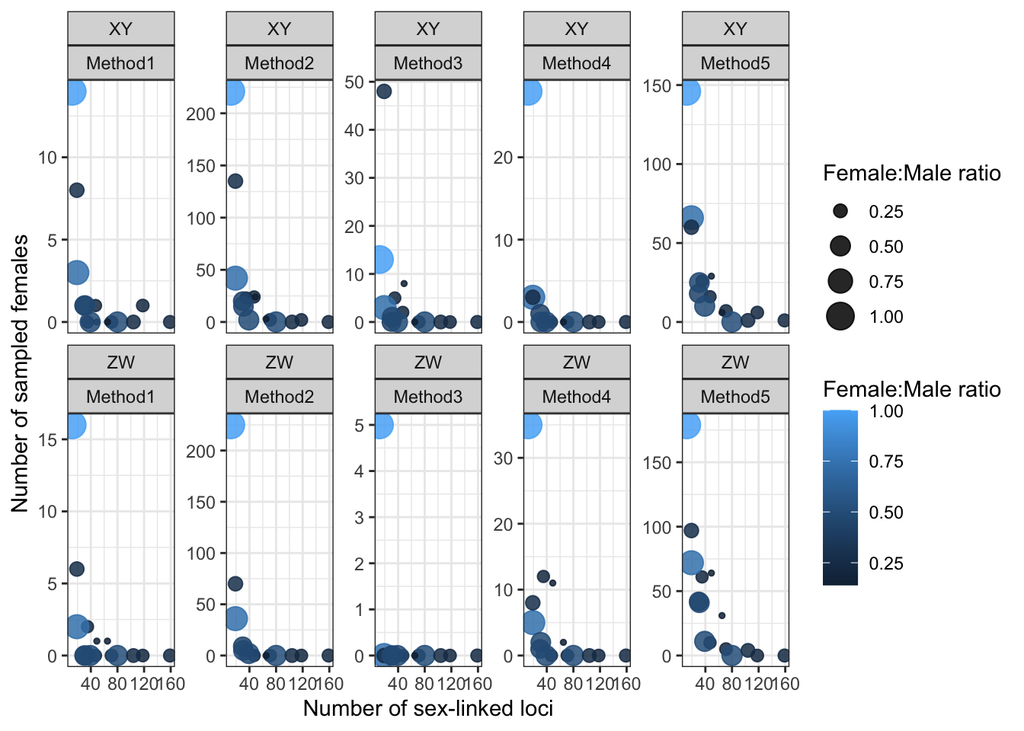

```r
ggplot(counts2) +
  geom_point(aes(x=Total, y=sexlinked, size=`Female:Male ratio`, colour=`Female:Male ratio`),alpha=0.85) +
  facet_wrap(SexDet ~ Method, scales = "free_y", ncol=5) +
  xlab("Number of sex-linked loci") +
  ylab("Number of sampled females") +
  theme_bw()
```

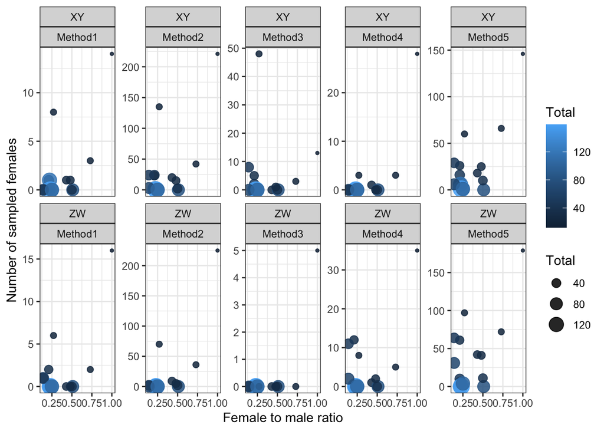

```r
ggplot(counts2) +
  geom_point(aes(y=sexlinked, x=`Female:Male ratio`, size=Total, colour=Total),alpha=0.85) +
  facet_wrap(SexDet~Method, ncol=5, scales = "free_y") +
  ylab("Number of sampled females") +
  xlab("Female to male ratio") +theme_bw()
```

It appears that Methods 1 to 3 identify more XY-linked than ZW-linked, while Method 4 and 5 do the opposite.

## 5. Plot results by scaffold

Now, let's assess co-localisation of markers from groups of markers (i.e., same Method, same SexDet, same species) that comprise significantly more markers than expected by chance.

```r
rm(my.counts, my.plots, plot.all, perm.counts, my.pops)
```

Retain only markers identified from methods that returned more sex-linked markers than expected by chance (at q 0.99)

```r
sig.methods <- counts %>%
  filter(significance=="**") %>%
  mutate(SigID = paste(Pop,Method,SexDet,sep = "_")) %>%
  pull(SigID)

my.sig <- my.df %>%
  mutate(SigID = paste(Pop,Method,SexDet,sep = "_")) %>%
  filter(SigID %in% sig.methods)
```

Count markers per scaffold, grouping by population, method and sex determination system

```r
SLbyScaf <- my.sig %>%
  group_by(Pop, Method, SexDet,Scaffold) %>%
  summarise(nSexLinked = n())
```

Calculate expected number of markers per scaffold from permutations

```r
SLbyScaf_perm <- my.perms %>%
  group_by(Pop, Method, SexDet,Scaffold,PermID) %>%
  summarise(SLbyScaf = n()) %>%
  filter(SLbyScaf > 1)
```

[output not shown]

```r
SLbyScaf_perm <- SLbyScaf_perm %>%
  group_by(Pop, Method, SexDet,Scaffold) %>%
  summarise(meanByScaf = mean(SLbyScaf),
            p95 = quantile(SLbyScaf, 0.95),
            p99 = quantile(SLbyScaf, 0.99)) %>%
  mutate(Scaffold = as.integer(Scaffold))
```

Create list of all possible combinations

```r
AllCombs <- expand_grid(Pop = unique(my.df$Pop),
                        Method = unique(my.df$Method),
                        SexDet = c("XY","ZW"),
                        Scaffold = as.double(unique(SLbyScaf_perm %>%
                                                       ungroup() %>% pull(Scaffold))))
```

Join observed and expected into one table

```r
SLbyScaf <- left_join(AllCombs, SLbyScaf %>% ungroup)
SLbyScaf <- left_join(SLbyScaf, SLbyScaf_perm)
SLbyScaf <- SLbyScaf %>% filter(is.na(nSexLinked)==FALSE) %>%
  mutate(meanByScaf = case_when(is.na(meanByScaf)==TRUE~0,
                                TRUE ~ meanByScaf),
         p95 = case_when(is.na(p95)==TRUE~0,
                                TRUE ~ p95),
         p99 = case_when(is.na(p99)==TRUE~0,
                                TRUE ~ p99)) %>%
  filter(Scaffold<14)
#we only detected one marker in scaffolds above 13, so we removed it
```

Identify significant ones

```r
SLbyScaf <- SLbyScaf %>%
  mutate(signif = case_when(nSexLinked > p99 ~ "**",
                            nSexLinked > p95 ~ "*",
                            TRUE ~ "ns"),
         SigID = paste(Pop,Method,SexDet, sep = "_"))
```

Save Table S8

```r
write_csv(SLbyScaf, file = "../6_Permutations/6_4_SignificanceTableByScaffold.csv")
```

Plot

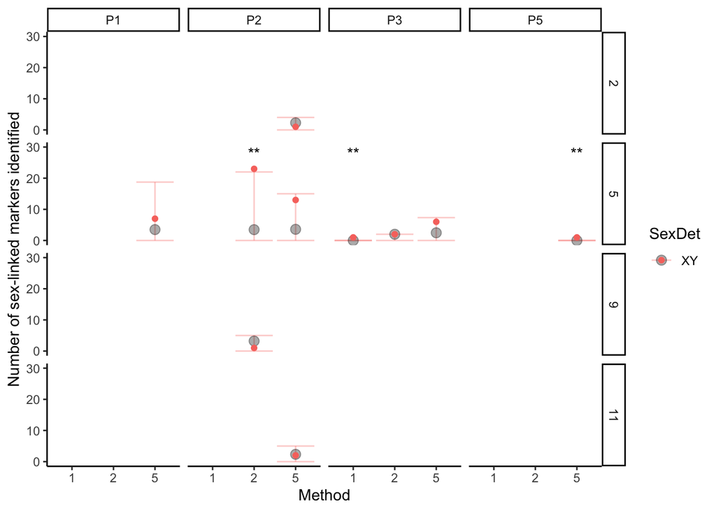

```r
sig.text.99 <- SLbyScaf %>% filter(signif == "**")
#sig.text.95 <- SLbyScaf %>% filter(signif == "*")

p1 <- ggplot(SLbyScaf) +
  geom_errorbar(aes(x=Method,
                    ymax=p99, ymin=0, colour=SexDet),
                  alpha = 1/3, position=position_dodge(width = 0.5)) +
  geom_point(aes(x=Method,y=meanByScaf,fill=SexDet),
               colour="black", alpha = 1/3, size=3,
               position=position_dodge(width = 0.5)) +
  geom_point(aes(x=Method, y=nSexLinked, fill=SexDet, colour=SexDet)) +
  geom_text(data=sig.text.99, aes(x=Method, y=28),label="**") +
  #geom_text(data=sig.text.95, aes(x=Method, y=20),label="*") +
  theme_classic() +
  ylab("Number of sex-linked markers identified") +
  facet_grid(Scaffold~Pop) +
  scale_x_discrete(labels=c("Method1" = "1", "Method2" = "2","Method5" = "5")) +
  scale_y_continuous(breaks = c(0,10,20,30), limits = c(0,30))

p1
```

```r
ggsave("../6_Permutations/6_5_SignificancePlotByScaffold.png",plot=p1,
       device = "png", width = 8,height = 10)
```